# [PGM2] Calcul de l’accessibilité d’une population à un service avec meric.osrm

Masters Géoprisme et Carthageo

Author

Claude Grasland

Published

September 1, 2025

```r
library(sf)
library(dplyr)
library(mapview)
```

## 1 Données

On souhaite mesurer l’accessibilité des habitants de la commune de Sucy-en-Brie à une pharmacie. On a extrait de la base de données INSEE Inracommunal des données relatives à l’offre et la demande

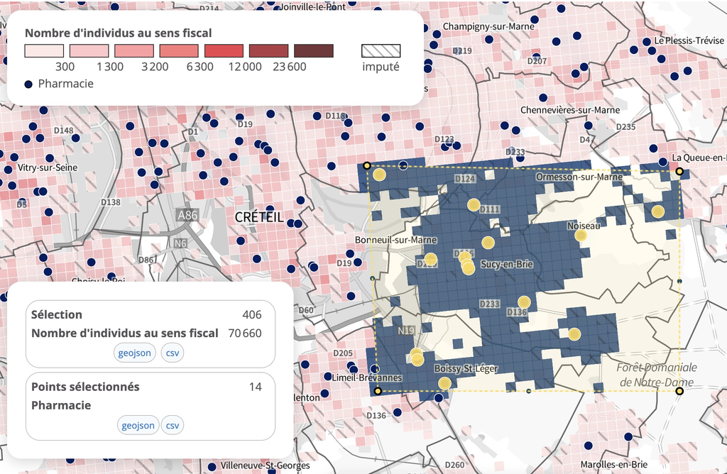

Extraction du site INSEE Infracommunal

### 1.1 Données sur l’offre

Le fichier comporte la localisation des pharmacies extraites du site de l’INSEE. On le lit à l’aide de la fonction *st_read()* du package **sf**.

```r
offre <- st_read("exo2/bpe.geojson")
class(offre)
```

```
[1] "sf"         "data.frame"
```

```r
head(offre)
```

```
Simple feature collection with 6 features and 5 fields
Geometry type: POINT
Dimension:     XY
Bounding box:  xmin: 2.505913 ymin: 48.74861 xmax: 2.573462 ymax: 48.78046
Geodetic CRS:  WGS 84
      id TYPEQU       LIB QUALITE_XY NB                  geometry
1 443757   D307 Pharmacie          B  1 POINT (2.549944 48.75772)
2 450644   D307 Pharmacie          B  1 POINT (2.551832 48.77605)
3 450669   D307 Pharmacie          B  1 POINT (2.573462 48.78046)
4 450451   D307 Pharmacie          B  1 POINT (2.513552 48.74861)
5 443760   D307 Pharmacie          B  1 POINT (2.535868 48.76366)
6 450449   D307 Pharmacie          B  1 POINT (2.505913 48.75296)
```

```r
st_crs(offre)
```

```
Coordinate Reference System:
  User input: WGS 84
  wkt:
GEOGCRS["WGS 84",
    DATUM["World Geodetic System 1984",
        ELLIPSOID["WGS 84",6378137,298.257223563,
            LENGTHUNIT["metre",1]]],
    PRIMEM["Greenwich",0,
        ANGLEUNIT["degree",0.0174532925199433]],
    CS[ellipsoidal,2],
        AXIS["geodetic latitude (Lat)",north,
            ORDER[1],
            ANGLEUNIT["degree",0.0174532925199433]],
        AXIS["geodetic longitude (Lon)",east,
            ORDER[2],
            ANGLEUNIT["degree",0.0174532925199433]],
    ID["EPSG",4326]]
```

La projection est de type EPSG=4326, c’est-à-dire latitudes et longitudes non projetées. On peut en effectuer une visualisation rapide avec le package **mapview** :

```r
mapview(offre)
```

[interactive chart not shown]

### 1.2 Données sur grille

On procède de la même façon pour le fichier relatif à la population sur grille de 200 m :

```r
grille <- st_read("exo2/grille.geojson")
class(grille)
```

```
[1] "sf"         "data.frame"
```

```r
head(grille)
```

```
Simple feature collection with 6 features and 20 fields
Geometry type: POLYGON
Dimension:     XY
Bounding box:  xmin: 2.554193 ymin: 48.74677 xmax: 2.578568 ymax: 48.77721
Geodetic CRS:  WGS 84
                             GEO GEO_OBJECT OBS_STATUS   lcog_geo ind  men
1 CRS3035RES200mN2875800E3774400      C200M          I      94048   3  1.1
2 CRS3035RES200mN2878800E3776200      C200M          I      94060   2  0.9
3 CRS3035RES200mN2876600E3774800      C200M          I      94071   8  2.7
4 CRS3035RES200mN2876800E3774800      C200M          A      94071  58 21.0
5 CRS3035RES200mN2876400E3774400      C200M          I 9404894004  17  5.8
6 CRS3035RES200mN2876600E3774400      C200M          A 9407194004  67 28.0
  men_pauv men_1ind men_5ind men_prop men_fmp   ind_snv men_surf men_coll
1      0.1      0.2      0.2      0.9     0.1   97357.1    147.8      0.2
2      0.2      0.2      0.0      0.6     0.1   48131.0     83.2      0.2
3      0.4      0.5      0.5      2.6     0.1  265825.6    389.1      0.0
4      1.0      3.0      2.0     21.0     1.0 2141520.5   3617.0      0.0
5      0.9      1.1      1.1      5.6     0.2  564879.5    826.9      0.0
6      1.0      6.0      1.0     27.0     2.0 2446740.5   3890.0      0.0
  men_mais log_soc ind_inc  log ind_0_17 ind_65p                       geometry
1      0.9       0       0  1.1      0.3     0.7 POLYGON ((2.557969 48.74875...
2      0.7       0       0  0.9      0.3     0.4 POLYGON ((2.578311 48.77721...
3      2.7       0       0  2.7      2.1     1.1 POLYGON ((2.562304 48.75627...
4     21.0       0       0 21.0     17.0    13.0 POLYGON ((2.562046 48.75806...
5      5.8       0       0  5.8      4.3     2.3 POLYGON ((2.557154 48.75412...
6     28.0       0       0 28.0     14.0    24.0 POLYGON ((2.556896 48.75591...
```

```r
st_crs(grille)
```

```
Coordinate Reference System:
  User input: WGS 84
  wkt:
GEOGCRS["WGS 84",
    DATUM["World Geodetic System 1984",
        ELLIPSOID["WGS 84",6378137,298.257223563,
            LENGTHUNIT["metre",1]]],
    PRIMEM["Greenwich",0,
        ANGLEUNIT["degree",0.0174532925199433]],
    CS[ellipsoidal,2],
        AXIS["geodetic latitude (Lat)",north,
            ORDER[1],
            ANGLEUNIT["degree",0.0174532925199433]],
        AXIS["geodetic longitude (Lon)",east,
            ORDER[2],
            ANGLEUNIT["degree",0.0174532925199433]],
    ID["EPSG",4326]]
```

La projection est de toujours type EPSG=4326, c’est-à-dire latitudes et longitudes non projetées. On peut en effectuer une visualisation rapide avec le package **mapview** :

```r
mapview(grille)
```

[interactive chart not shown]

### 1.3 Données sur la demande

On va transformer le fonds de carte pour obtenir les centroïdes et afficher des cercles proportionnels à la population des carreaux. Ici on choisit de prendre comme demande le nombre total d’individus et on negarde que les carreaux de Sucy-en-Brie

```r
demande <- grille %>% st_centroid() %>%
                      filter(substr(lcog_geo,1,5)=="94071")%>%
                      select(id=GEO, size=ind)
```

On représente sur une même carte l’offre et la demande :

```r
map1 <- mapview(offre,
                col.regions="red",
                alpha.regions=1)
map2 <- mapview(demande,
                cex="size",
                col.regions="blue",
                legend = F)
map<-map1+map2
map
```

[interactive chart not shown]

## 2 Calcul de l’accessibilité

### 2.1 Utilisation de metric.osrm

On utilise le package metric.osrm pour calculer la distance routière en temps entre toutes les origines et toutes les destinations. Voici le programme typique de calcul :

```r
library(metric.osrm)

# Choix du serveur
options(osrm.server = "https://metric-osrm-backend.lab.sspcloud.fr/")

# Specification du profil
options(osrm.profile = "driving")

# préparation des données
# (Osrm attends des fichiers de type id/lat/lon)
#coo <-st_coordinates(offre)
#offre$lon<-coo[,1]
#offre$lat <- coo[,2]

coo <-st_coordinates(demande)
demande$lon<-coo[,1]
demande$lat <- coo[,2]


# Requête
tab<-metricOsrmTable(src = demande,
                       dst = offre,
                       duree = TRUE,
                       faceAFace = F,
                       distance = TRUE,
                       allerRetour = FALSE,
                       optiMeasure = "duree",
                       nbDstVolOiseau =  3,  # Nb de dist. euclidiennes présélectionnées
                       nbDstMeasure = 1,  # Nb de dist routières retenues
                       exclude ="ferry")

head(tab)
```

```
  ID                          idSrc  lonSrc   latSrc  idDst  lonDst   latDst
1  1 CRS3035RES200mN2876600E3774400 2.55568 48.75468 443757 2.54991 48.75779
2  2 CRS3035RES200mN2876600E3774600 2.55889 48.75505 443757 2.54991 48.75779
3  3 CRS3035RES200mN2876600E3774800 2.55963 48.75577 443757 2.54991 48.75779
4  4 CRS3035RES200mN2876800E3772800 2.53372 48.75531 443760 2.53588 48.76367
5  5 CRS3035RES200mN2876800E3773000 2.53634 48.75573 443757 2.54991 48.75779
6  6 CRS3035RES200mN2876800E3773200 2.53888 48.75548 443757 2.54991 48.75779
  duree distance
1  2.92    1.594
2  4.23    1.765
3  4.26    1.778
4  3.24    1.576
5  3.11    1.224
6  3.04    1.161
```

A noter que la requête peut prendre plus ou moins de temps selon la taille du calcul (nb origines x nb destinations).

### 2.2 Jointure avec la grille

On effectue une jointure avec les données de grille

```r
grille <- merge(grille, tab, by.x="GEO",by.y="idSrc")
```

### 2.3 Calcul des fréquences cumulées

On choisit une population et une distance puis on construit la courbe indiquant la part des personnes ayant accès au service en dessous d’une certaine distance.

```r
# Choix de la population et de la distance
pop <- grille$ind
dis <- grille$duree

# Ajout de labels
nompop <- "% des individus"
nomdis <- "distance routière en minutes"

# Création d'un tableau
tab<-data.frame(pop,dis)

# Transformation de la population en fréquence
tab$pct <- 100*tab$pop/sum(tab$pop)

# Tri du tableau par distances croissantes
tab <- tab[order(tab$dis),]

# Calcul de la fréquence cumulée ascendante
tab$pctcum <- cumsum(tab$pct)

# Calcul de l'accessibilité moyenne pondéree
moy = sum(tab$dis*tab$pct)/100
paste("L'accessibilité moyenne est de ", round(moy,1), "minutes")
```

```
[1] "L'accessibilité moyenne est de  1.7 minutes"
```

```r
# Affichage du tableau
head(tab)
```

```
      pop  dis       pct   pctcum
116 562.0 0.03 2.1178776 2.117878
61   68.5 0.15 0.2581399 2.376017
133 330.5 0.18 1.2454778 3.621495
22   74.5 0.28 0.2807507 3.902246
105 179.5 0.48 0.6764396 4.578686
104 247.0 0.50 0.9308110 5.509497
```

### 2.4 Graphique d’accessibilité

#### Avec R-base

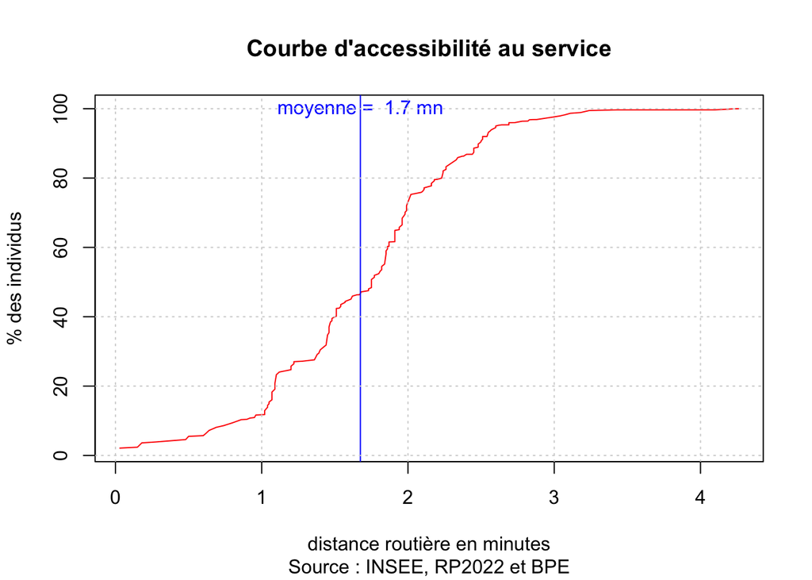

```r
plot(tab$dis,tab$pctcum,
     type="l",
     col="red",
     xlab = nomdis,
     ylab = nompop,
     main = "Courbe d'accessibilité au service",
     sub = "Source : INSEE, RP2022 et BPE")
abline(v=moy,col="blue")
text(moy,100,paste("moyenne = ",round(moy,1), "mn"),col="blue")
grid()
```

#### Avec ggplot

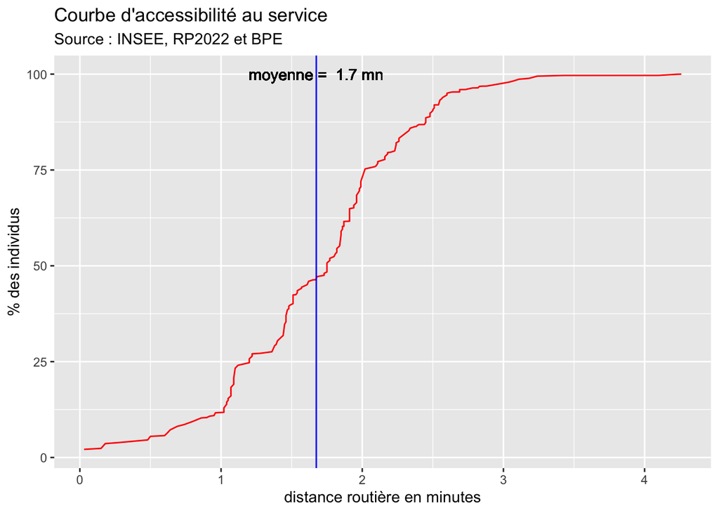

```r
library(ggplot2)
g<- ggplot(tab) + aes(x=dis, y=pctcum) +
                  geom_line(col="red") +
                  scale_x_continuous(nomdis) +
                  scale_y_continuous(nompop) +
                  geom_vline(xintercept=moy,col="blue")+
                  geom_text(aes(x=moy,y=100, label=paste("moyenne = ",round(moy,1), "mn")))+
                  ggtitle(label = "Courbe d'accessibilité au service",
                          subtitle = "Source : INSEE, RP2022 et BPE")
g
```

## 3 Cartographie

On peut l’effectuer sur les supports de son choix (Qgis, Magrit, etc, …). Le résultat devrait ressembler à ceci :

```r
map1 <- mapview(offre,
                col.regions="red",
                alpha.regions=1)
map2 <- mapview(grille,
                zcol = "duree",
                cat = c(0, moy, 2*moy, 3*moy, max(moy)),
                col.regions=c("green","lightyellow","yellow","orange"),
                legend = T)
map<-map2+map1
map
```

[interactive chart not shown]